# DataAnalysis.Rmd

Meg Britt

Load the required libraries for this activity.

```r
library("ggplot2")
library("knitr")
library("dplyr")
```

Import the data that was created in Part 1, and remove unnecessary column.

```r
Mdata<-read.csv("Data/measurements.csv")
Mdata$X<-NULL
```

Rename the columns to three letter abbreviations for simplicity and transform values to one matching unit.

```r
Mdata2<-rename(Mdata,Spc.=Species,wdt.=limb.width, lth.=limb.length, w.un=unitsW, l.un=unitsL)
Mdata2$w.un <- "cm"
Mdata2$wdt.<-if_else(Mdata2$w.un=="mm", Mdata2$wdt.*10, Mdata2$wdt.)
Mdata2$w.un <- "cm"
Mdata2$lth.<-if_else(Mdata2$l.un=="mm", Mdata2$lth.*10, Mdata2$lth.)
Mdata2$l.un <- "cm"
```

Calculate the volume of limbs.

```r
Mdata2$Volume <- with(Mdata2, pi*(((wdt.)/2)^2)*(lth.))
```

Group the species based on whether their limb width is above or below 10 cm and create a new bject for these groups.

```r
Mdata2$group<-ifelse(Mdata2$wdt. >10, ">10cm.width","<10cm.width")
X <- group_by(Mdata2, group)
```

Create a new object that summarizes the data by group type.

```r
Y <- summarise(X, Volume_Avg=mean(Volume), Volume_SD= sd(Volume), Length_Avg=mean(lth.), Length_SD = sd(lth.), Width_Avg = mean(wdt.), Width_SD = sd(wdt.))
```

Create a table for measurements of all species.

```r
kable(Y, caption = "Table 1: Average (Avg) and Standard Deviation (SD) of Volume, Length, and Width for Species with above and below limb width of 10cm")
```

Table 1: Average (Avg) and Standard Deviation (SD) of Volume, Length, and Width for Species with above and below limb width of 10cm

| group | Volume_Avg | Volume_SD | Length_Avg | Length_SD | Width_Avg | Width_SD |
| --- | --- | --- | --- | --- | --- | --- |
| <10cm.width | 42568.17 | 41455.71 | 1393.389 | 858.3068 | 5.981681 | 2.374671 |
| >10cm.width | 137475.42 | 109787.81 | 1123.992 | 910.8960 | 12.033238 | 2.480623 |

Plot the length and width data for all species.

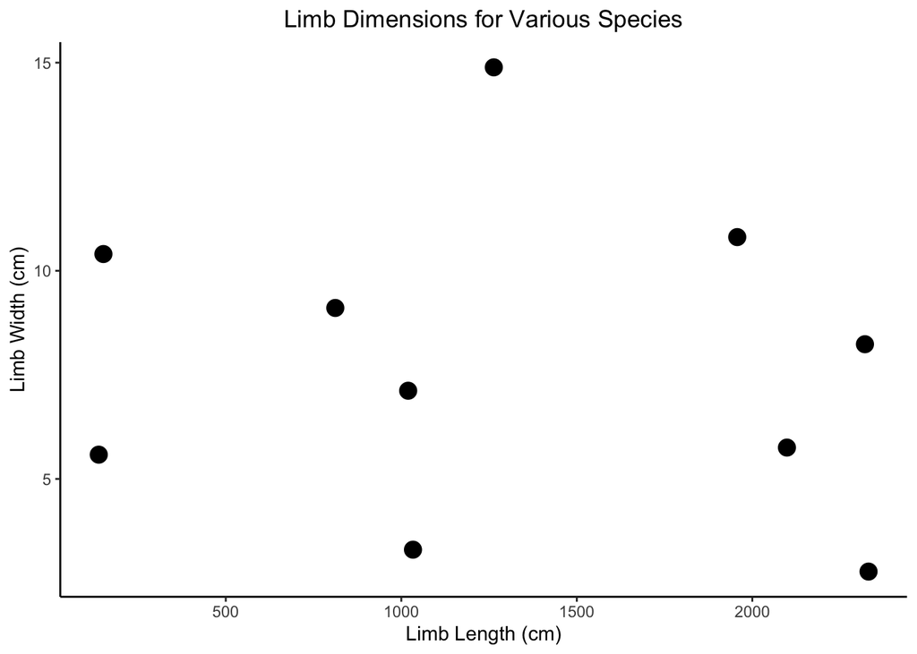

```r
ggplot(data = Mdata2, aes(x=lth., y=wdt.)) + geom_point(size = 4) + theme_classic() + ggtitle("Limb Dimensions for Various Species") + theme(plot.title = element_text(hjust = 0.5)) + labs(x = "Limb Length (cm)", y = "Limb Width (cm)")
```

Calculate the average limb volume for all species.

```r
Volume.avg <- mean(Mdata2$Volume)
```

Pull out the volume data only for species that have above average limb volume

```r
Above.avg.Vol <- filter(Mdata2, Volume > Volume.avg)
```

Plot width and length only for species that have aboveaverage volume.

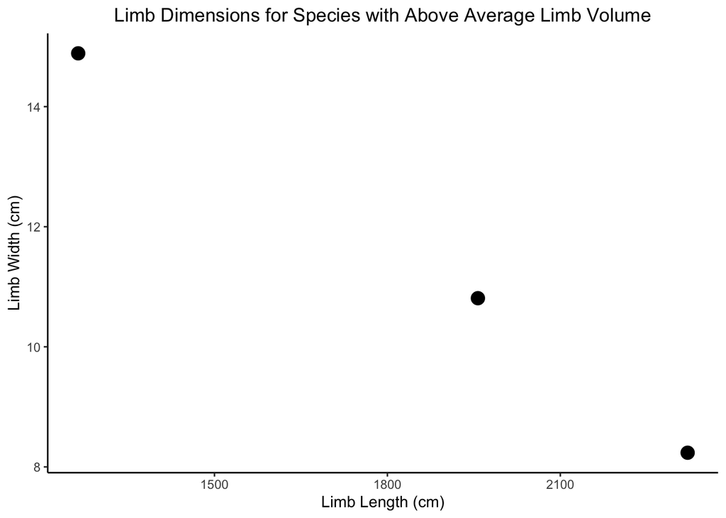

```r
ggplot(data = Above.avg.Vol, aes(x=lth., y=wdt.)) + geom_point(size = 4) + theme_classic() + ggtitle("Limb Dimensions for Species with Above Average Limb Volume") + theme(plot.title = element_text(hjust = 0.5)) + labs(x = "Limb Length (cm)", y = "Limb Width (cm)")
```

Pull out the volume data only for species that have a below average volume.

```r
Below.avg.Vol <- filter(Mdata2, Volume < Volume.avg)
```

Create a new object that only includes species data and volume for species with below average volume and display in a table.

```r
Vol.below.avg.spc.only <- Below.avg.Vol[c("Spc.","Volume")]
kable(Vol.below.avg.spc.only, caption = "Table 2: Volume for species with below average volume")
```

Table 2: Volume for species with below average volume

| Spc. | Volume |
| --- | --- |
| Pseudacris crucifer | 12864.282 |
| Ascaphus truei | 54552.054 |
| Bombina bomina | 52893.765 |
| Discoglossus galganoi | 8838.710 |
| Megaphrys nastua | 14088.009 |
| Pelobates fuscus | 40581.182 |
| Rhinophrynus dorsalis | 3381.795 |